# Balance Assessment and Survival Analysis | Tz/Dz/Az vs 5ARI

Jacob Simmering, PhD https://jacobsimmering.com (University of Iowa)https://uiowa.edu  
2023-11-09

```r
library("Rcpp")
library(tidyverse)
library(gtsummary)
library(survival)
library(effectsize)
library(patchwork)
```

This file was compiled on 2023-11-09 13:21:08 by `jsimmeri` on MNF091. The script `analysis_functions.R` provides:

1. some functions for summarizing the cohort and building tables that are shared across scripts
2. code to load the entire collection out outcomes data (which it returns as `model_data` to the workspace)
3. sets `root_dir` according to the location where the script is being run to handle different syntax for referring to network drives in MacOS and CentOS

```r
source("~/projects/dlb-tz/analysis/analysis_functions.R")
```

## Data Load

### Unadjusted Data

The tibble `model_data` is loaded by `analysis_functions` `model_data` contains data on all users of the three drugs. We want to reduce that here to just Tz/Dz/Az and 5ARI.

```r
model_data <- model_data %>%
  filter(two_rx == TRUE) %>%
  filter(drug %in% c("5ari", "tz/dz/az")) %>%
  mutate(treatment = drug == "tz/dz/az")
```

### Matches

We also want to load our matching results:

```r
matches <- read_rds(glue::glue("/{shared_dir}/lss_jsimmeri/LBD/matches_tz_5ari_2rx.rds"))
```

And using the matches, build matched versions of the tamsulosin versus 5ARI model data:

```r
matched_model_data <- model_data %>%
  select(-treatment) %>%
  inner_join(matches,
    by = "enrolid")
```

## Balance and Cohort Description

### Before Matching

```r
describe_cohort(model_data)
```

| Group | Characteristic | 5ari, N = 80,158 | tz/dz/az, N = 126,313 | Difference |
| --- | --- | --- | --- | --- |
| Age and Medication Start Time | Age at Index Date | 62 (54, 71) | 62 (55, 70) | -0.04 |
|  | Medication Index Date | 2,010.0 (2,008.0, 2,013.0) | 2,009.0 (2,006.0, 2,012.0) | 0.22 |
| Duration of Enrollment Time | Lookback Time (Years) | 3.16 (1.84, 5.59) | 2.86 (1.71, 5.19) | 0.07 |
|  | Follow Up Time (Years) | 2.23 (0.98, 4.42) | 1.96 (0.93, 4.19) | 0.05 |
| Rates of Inpatient and Outpatient Encounters | Inpatient Events Per Year | 0.00 (0.00, 0.00) | 0.00 (0.00, 0.13) | -0.11 |
|  | Outpatient Events Per Year | 9 (5, 16) | 9 (5, 16) | -0.05 |
|  | Mean Number of DX Codes Per Outpatient Event | 1.40 (1.20, 1.87) | 1.36 (1.18, 1.83) | 0.04 |
|  | Outpatient DX Code Incidence Per Year | 0.04 (0.02, 0.07) | 0.04 (0.02, 0.07) | -0.03 |
|  | mean_ndx_out_rate | 13 (7, 24) | 14 (7, 25) | -0.03 |
| Elixhauser/AHRQ Comorbidity Flags | Alcohol Abuse | 1,152 (1.4%) | 2,680 (2.1%) | 0.02 |
|  | Anemia | 9,308 (11.6%) | 17,016 (13.5%) | 0.03 |
|  | Blood Loss | 913 (1.1%) | 1,514 (1.2%) | 0.00 |
|  | Heart Failure | 5,398 (6.7%) | 10,207 (8.1%) | 0.02 |
|  | Coagulopathy | 2,360 (2.9%) | 3,645 (2.9%) | 0.00 |
|  | Depression | 5,527 (6.9%) | 8,991 (7.1%) | 0.00 |
|  | Diabetes Without Complications | 15,970 (19.9%) | 36,574 (29.0%) | 0.10 |
|  | Diabetes With Complications | 5,141 (6.4%) | 14,387 (11.4%) | 0.08 |
|  | Drug Abuse | 576 (0.7%) | 1,331 (1.1%) | 0.02 |
|  | Fluid or Electrolyte Disorders | 6,001 (7.5%) | 13,805 (10.9%) | 0.06 |
|  | HIV | 548 (0.7%) | 486 (0.4%) | 0.02 |
|  | HTN Without Complications | 42,463 (53.0%) | 87,650 (69.4%) | 0.17 |
|  | HTN With Complications | 7,995 (10.0%) | 20,761 (16.4%) | 0.09 |
|  | Hypothyroidism | 7,062 (8.8%) | 9,809 (7.8%) | 0.02 |
|  | Liver Disease | 2,476 (3.1%) | 4,845 (3.8%) | 0.02 |
|  | Lymphoma | 844 (1.1%) | 1,322 (1.0%) | 0.00 |
|  | Metastatic Cancer | 1,108 (1.4%) | 1,555 (1.2%) | 0.01 |
|  | Other Neurologic Disorders | 5,252 (6.6%) | 8,237 (6.5%) | 0.00 |
|  | Obesity | 4,530 (5.7%) | 11,470 (9.1%) | 0.06 |
|  | Paralysis | 1,006 (1.3%) | 2,087 (1.7%) | 0.02 |
|  | Pulmonary Hypertension | 1,592 (2.0%) | 2,458 (1.9%) | 0.00 |
|  | Psychoses | 4,257 (5.3%) | 6,910 (5.5%) | 0.00 |
|  | Peptic Ulcer Disease | 185 (0.2%) | 297 (0.2%) | 0.00 |
|  | COPD | 14,266 (17.8%) | 24,107 (19.1%) | 0.02 |
|  | Peripheral Vascular Disease | 8,516 (10.6%) | 15,324 (12.1%) | 0.02 |
|  | Renal Failure | 3,543 (4.4%) | 12,096 (9.6%) | 0.09 |
|  | Rheumatoid Arthritis | 2,857 (3.6%) | 4,754 (3.8%) | 0.01 |
|  | Solid Tumor | 10,567 (13.2%) | 13,905 (11.0%) | 0.03 |
|  | Valvular Disease | 9,339 (11.7%) | 14,081 (11.1%) | 0.01 |
|  | Weight Loss | 2,322 (2.9%) | 3,448 (2.7%) | 0.00 |
| Hypotension | Orthostatic Hypotension | 823 (1.0%) | 944 (0.7%) | 0.01 |
|  | Other Hypotension | 1,532 (1.9%) | 2,202 (1.7%) | 0.01 |
| Prostate Specific Antigen | PSA Measurement Taken | 48,463 (60.5%) | 72,215 (57.2%) | 0.03 |
|  | Diagnosis of Abnormal PSA | 23,789 (29.7%) | 14,099 (11.2%) | 0.23 |
| Bladder Function and Urinary Flow | Slow Urinary Stream Diagnosis | 1,963 (2.4%) | 2,948 (2.3%) | 0.00 |
|  | Uroflow Study Performed | 5,672 (7.1%) | 7,684 (6.1%) | 0.02 |
|  | Cystometrogram Performed | 546 (0.7%) | 937 (0.7%) | 0.00 |
|  | Diagnosis of BPH | 36,166 (45.1%) | 42,481 (33.6%) | 0.12 |
| Other Comorbidities | Diagnosis of Anxiety | 5,501 (6.9%) | 7,827 (6.2%) | 0.01 |
|  | Diagnosis of Erectile Dysfunction | 7,248 (9.0%) | 11,268 (8.9%) | 0.00 |

### After Matching

```r
describe_cohort(matched_model_data)
```

| Group | Characteristic | 5ari, N = 65,436 | tz/dz/az, N = 65,436 | Difference |
| --- | --- | --- | --- | --- |
| Age and Medication Start Time | Age at Index Date | 62 (54, 70) | 62 (54, 70) | 0.01 |
|  | Medication Index Date | 2,010.0 (2,007.0, 2,013.0) | 2,010.0 (2,007.0, 2,012.0) | 0.03 |
| Duration of Enrollment Time | Lookback Time (Years) | 3.10 (1.82, 5.47) | 3.02 (1.79, 5.44) | 0.01 |
|  | Follow Up Time (Years) | 2.16 (0.95, 4.36) | 2.15 (0.94, 4.36) | 0.00 |
| Rates of Inpatient and Outpatient Encounters | Inpatient Events Per Year | 0.00 (0.00, 0.00) | 0.00 (0.00, 0.00) | 0.00 |
|  | Outpatient Events Per Year | 9 (5, 16) | 9 (5, 16) | 0.00 |
|  | Mean Number of DX Codes Per Outpatient Event | 1.40 (1.19, 1.87) | 1.39 (1.19, 1.85) | 0.02 |
|  | Outpatient DX Code Incidence Per Year | 0.04 (0.02, 0.07) | 0.04 (0.02, 0.07) | 0.01 |
|  | mean_ndx_out_rate | 13 (7, 24) | 13 (7, 24) | 0.01 |
| Elixhauser/AHRQ Comorbidity Flags | Alcohol Abuse | 1,051 (1.6%) | 1,079 (1.6%) | 0.00 |
|  | Anemia | 7,762 (11.9%) | 7,674 (11.7%) | 0.00 |
|  | Blood Loss | 741 (1.1%) | 735 (1.1%) | 0.00 |
|  | Heart Failure | 4,556 (7.0%) | 4,509 (6.9%) | 0.00 |
|  | Coagulopathy | 1,898 (2.9%) | 1,906 (2.9%) | 0.00 |
|  | Depression | 4,642 (7.1%) | 4,687 (7.2%) | 0.00 |
|  | Diabetes Without Complications | 14,164 (21.6%) | 14,190 (21.7%) | 0.00 |
|  | Diabetes With Complications | 4,712 (7.2%) | 4,615 (7.1%) | 0.00 |
|  | Drug Abuse | 536 (0.8%) | 549 (0.8%) | 0.00 |
|  | Fluid or Electrolyte Disorders | 5,295 (8.1%) | 5,175 (7.9%) | 0.00 |
|  | HIV | 373 (0.6%) | 364 (0.6%) | 0.00 |
|  | HTN Without Complications | 36,898 (56.4%) | 36,836 (56.3%) | 0.00 |
|  | HTN With Complications | 7,217 (11.0%) | 7,176 (11.0%) | 0.00 |
|  | Hypothyroidism | 5,620 (8.6%) | 5,529 (8.4%) | 0.00 |
|  | Liver Disease | 2,141 (3.3%) | 2,174 (3.3%) | 0.00 |
|  | Lymphoma | 692 (1.1%) | 682 (1.0%) | 0.00 |
|  | Metastatic Cancer | 884 (1.4%) | 849 (1.3%) | 0.00 |
|  | Other Neurologic Disorders | 4,342 (6.6%) | 4,276 (6.5%) | 0.00 |
|  | Obesity | 4,184 (6.4%) | 4,078 (6.2%) | 0.00 |
|  | Paralysis | 879 (1.3%) | 899 (1.4%) | 0.00 |
|  | Pulmonary Hypertension | 1,299 (2.0%) | 1,270 (1.9%) | 0.00 |
|  | Psychoses | 3,560 (5.4%) | 3,627 (5.5%) | 0.00 |
|  | Peptic Ulcer Disease | 148 (0.2%) | 155 (0.2%) | 0.00 |
|  | COPD | 11,867 (18.1%) | 12,002 (18.3%) | 0.00 |
|  | Peripheral Vascular Disease | 7,133 (10.9%) | 7,033 (10.7%) | 0.00 |
|  | Renal Failure | 3,354 (5.1%) | 3,296 (5.0%) | 0.00 |
|  | Rheumatoid Arthritis | 2,404 (3.7%) | 2,386 (3.6%) | 0.00 |
|  | Solid Tumor | 8,165 (12.5%) | 8,205 (12.5%) | 0.00 |
|  | Valvular Disease | 7,501 (11.5%) | 7,446 (11.4%) | 0.00 |
|  | Weight Loss | 1,892 (2.9%) | 1,875 (2.9%) | 0.00 |
| Hypotension | Orthostatic Hypotension | 609 (0.9%) | 592 (0.9%) | 0.00 |
|  | Other Hypotension | 1,233 (1.9%) | 1,205 (1.8%) | 0.00 |
| Prostate Specific Antigen | PSA Measurement Taken | 38,893 (59.4%) | 38,607 (59.0%) | 0.00 |
|  | Diagnosis of Abnormal PSA | 13,387 (20.5%) | 13,044 (19.9%) | 0.01 |
| Bladder Function and Urinary Flow | Slow Urinary Stream Diagnosis | 1,639 (2.5%) | 1,687 (2.6%) | 0.00 |
|  | Uroflow Study Performed | 4,499 (6.9%) | 4,809 (7.3%) | 0.01 |
|  | Cystometrogram Performed | 483 (0.7%) | 530 (0.8%) | 0.00 |
|  | Diagnosis of BPH | 27,327 (41.8%) | 27,707 (42.3%) | 0.01 |
| Other Comorbidities | Diagnosis of Anxiety | 4,458 (6.8%) | 4,427 (6.8%) | 0.00 |
|  | Diagnosis of Erectile Dysfunction | 5,914 (9.0%) | 6,032 (9.2%) | 0.00 |

## Propensity Score Overlap

We can also visually inspect the estimated propensity scores for overlap:

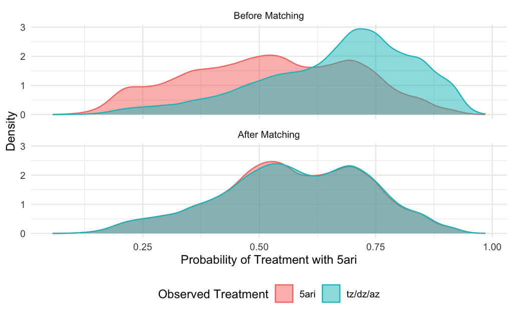

```r
ps <- read_rds(glue::glue("/{shared_dir}/lss_jsimmeri/LBD/model_tz_5ari_2rx.rds"))
bind_rows(
  model_data %>%
    inner_join(ps, by = "enrolid") %>%
    mutate(type = "Before Matching"),
  matched_model_data %>%
    inner_join(ps, by = "enrolid") %>%
    mutate(type = "After Matching")
  ) %>%
  mutate(type = forcats::fct_rev(type)) %>%
  ggplot(aes(x = ptx, fill = drug, color = drug)) +
  geom_density(alpha = 0.5) +
  labs(x = "Probability of Treatment with 5ari",
       y = "Density",
       color = "Observed Treatment",
       fill = "Observed Treatment") +
  theme_minimal() +
  theme(legend.position = "bottom") +
  facet_wrap(~ type, nrow = 2)
```

It is visually apparent that the two cohorts have a limited overlap before matching, which is largely addressed with matching.

## Survival Analysis

### Before Matching

```r
km_unadjust <-survfit(Surv(survival_time, develops_pd) ~ treatment,
        data = model_data) %>%
  broom::tidy() %>%
  mutate(treatment = ifelse(strata == "treatment=TRUE",
    "tz/dz/az", "5ARI")) %>%
  ggplot(
    aes(
      x = time / 365,
      y = 100 * estimate,
      ymin = 100 * conf.low,
      ymax = 100 * conf.high
    )
  ) +
  geom_step(aes(color = treatment)) +
  geom_ribbon(aes(fill = treatment), alpha = 0.25) +
  theme_minimal() +
  labs(x = "Years of Follow Up", y = "Percent Remaining LBD Free",
       color = "", fill = "") +
  theme(legend.position = c(0.25, 0.25))
```

A finding that is statistically significant using the log rank test:

```r
survdiff(Surv(survival_time, develops_pd) ~ treatment,
         data = model_data)
```

```
Call:
survdiff(formula = Surv(survival_time, develops_pd) ~ treatment,
    data = model_data)

                     N Observed Expected (O-E)^2/E (O-E)^2/V
treatment=FALSE  80158      193      155      9.29      15.5
treatment=TRUE  126313      195      233      6.18      15.5

 Chisq= 15.5  on 1 degrees of freedom, p= 8e-05
```

```r
raw_cox <- coxph(Surv(survival_time, develops_pd) ~ as.numeric(treatment),
                 data = model_data,
                 robust = TRUE)
tbl_regression(raw_cox, exponentiate = TRUE)
```

| **Characteristic** | **HR**<sup>1</sup> | **95% CI**<sup>1</sup> | **p-value** |
| --- | --- | --- | --- |
| as.numeric(treatment) | 0.67 | 0.55, 0.82 | <0.001 |

<sup>1</sup> HR = Hazard Ratio, CI = Confidence Interval

However, this estimate is not trustworthy as we know the groups could be better balanced.

### With Propensity Score Matching

Further adjustment yields similar results:

We observe the following overall incidence:

```r
matched_model_data %>%
  group_by(drug) %>%
  summarize(
    cases = sum(develops_pd),
    time = sum(survival_time / 365),
    incidence = cases / time * 10000
  ) %>%
  knitr::kable()
```

| drug | cases | time | incidence |
| --- | --- | --- | --- |
| 5ari | 152 | 199755.3 | 7.609309 |
| tz/dz/az | 111 | 199560.7 | 5.562218 |

With a Kaplan Meier curve:

```r
km_adjust <-survfit(Surv(survival_time, develops_pd) ~ drug,
        data = matched_model_data) %>%
  broom::tidy() %>%
  mutate(treatment = ifelse(strata == "drug=5ari",
    "5ARI", "TZ/DZ/AZ")) %>%
  ggplot(
    aes(
      x = time / 365,
      y = 100 * estimate,
      ymin = 100 * conf.low,
      ymax = 100 * conf.high
    )
  ) +
  geom_step(aes(color = treatment)) +
  geom_ribbon(aes(fill = treatment), alpha = 0.25) +
  theme_minimal() +
  labs(x = "Years of Follow Up", y = "Percent Remaining LBD Free",
       color = "", fill = "") +
  theme(legend.position = c(0.25, 0.25))
```

The population size at risk by year is given in the table below:

```r
survfit(Surv(survival_time, develops_pd) ~ drug,
        data = matched_model_data) %>%
  broom::tidy() %>%
  select(strata, time,, n.risk) %>%
  complete(strata, time = 0:(16*365)) %>%
  fill(n.risk, .direction = "down") %>%
  mutate(drug = ifelse(strata == "drug=5ari", "5ARI", "TZ/DZ/AZ")) %>%
  select(time, drug, n.risk) %>%
  filter(time %in% c(1:16 * 365)) %>%
  mutate(year = round(time / 365)) %>%
  spread(drug, n.risk) %>%
  knitr::kable()
```

| time | year | 5ARI | TZ/DZ/AZ |
| --- | --- | --- | --- |
| 365 | 1 | 47984 | 47825 |
| 730 | 2 | 34212 | 34101 |
| 1095 | 3 | 24928 | 24858 |
| 1460 | 4 | 18265 | 18201 |
| 1825 | 5 | 13244 | 13216 |
| 2190 | 6 | 9506 | 9543 |
| 2555 | 7 | 6775 | 6793 |
| 2920 | 8 | 4596 | 4595 |
| 3285 | 9 | 3058 | 3042 |
| 3650 | 10 | 1913 | 1926 |
| 4015 | 11 | 1109 | 1101 |
| 4380 | 12 | 553 | 525 |
| 4745 | 13 | 273 | 275 |
| 5110 | 14 | 118 | 135 |
| 5475 | 15 | 34 | 33 |
| 5840 | 16 | 2 | 1 |

A log rank test confirms that the curves remain different.

```r
survdiff(Surv(survival_time, develops_pd) ~ treatment,
         data = matched_model_data)
```

```
Call:
survdiff(formula = Surv(survival_time, develops_pd) ~ treatment,
    data = matched_model_data)

                N Observed Expected (O-E)^2/E (O-E)^2/V
treatment=0 65436      152      132      3.18      6.37
treatment=1 65436      111      131      3.18      6.37

 Chisq= 6.4  on 1 degrees of freedom, p= 0.01
```

Survival times

```r
tbl_survfit(
  survfit(
    Surv(survival_time, develops_pd) ~ drug, data = matched_model_data
  ),
  probs = seq(0.5, 2, by = 0.5) / 100
)
```

| **Characteristic** | **0.5% Percentile** | **1.0% Percentile** | **1.5% Percentile** | **2.0% Percentile** |
| --- | --- | --- | --- | --- |
| drug |  |  |  |  |
| 5ari | 2,202 (1,805, 3,097) | — (3,744, —) | — (—, —) | — (—, —) |
| tz/dz/az | 2,939 (2,338, 3,278) | 4,458 (3,963, —) | — (4,458, —) | — (—, —) |

We fit a Cox regression model to estimate the differences in hazard:

```r
full_cox <- coxph(Surv(survival_time, develops_pd) ~ as.numeric(treatment),
                       data = matched_model_data,
                       robust = TRUE)
tbl_regression(full_cox, exponentiate = TRUE)
```

| **Characteristic** | **HR**<sup>1</sup> | **95% CI**<sup>1</sup> | **p-value** |
| --- | --- | --- | --- |
| as.numeric(treatment) | 0.73 | 0.57, 0.93 | 0.012 |

<sup>1</sup> HR = Hazard Ratio, CI = Confidence Interval

## Fit Summaries

```r
tbl_merge(
  tbls = list(
    tbl_regression(raw_cox, exponentiate = TRUE),
    tbl_regression(full_cox, exponentiate = TRUE)
  ),
  tab_spanner = c("Unadjusted", "Propensity Score Matched")
) %>%
  as_flex_table()
```

| Characteristic | Unadjusted HR1 | Unadjusted 95% CI1 | Unadjusted p-value | Propensity Score Matched HR1 | Propensity Score Matched 95% CI1 | Propensity Score Matched p-value |
| --- | --- | --- | --- | --- | --- | --- |
| as.numeric(treatment) | 0.67 | 0.55, 0.82 | <0.001 | 0.73 | 0.57, 0.93 | 0.012 |

1HR = Hazard Ratio, CI = Confidence Interval

## Diagnostics

```r
scf_residuals <- cox.zph(full_cox)
scf_residuals
```

```
                      chisq df     p
as.numeric(treatment)  5.25  1 0.022
GLOBAL                 5.25  1 0.022
```

```r
with(scf_residuals, cor.test(x, y))
```

```
    Pearson's product-moment correlation

data:  x and y
t = 2.3065, df = 261, p-value = 0.02187
alternative hypothesis: true correlation is not equal to 0
95 percent confidence interval:
 0.02073478 0.25788497
sample estimates:
     cor
0.141337
```

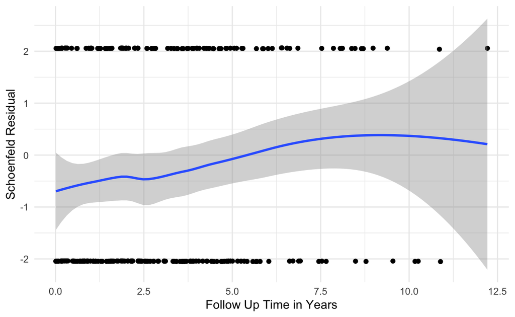

```r
tibble(
  x = scf_residuals$time,
  y = scf_residuals$y
) %>%
  ggplot(aes(x = x / 365, y = y)) +
  geom_point() +
  geom_smooth(method = "loess") +
  labs(x = "Follow Up Time in Years", y = "Schoenfeld Residual") +
  theme_minimal()
```